# Processos relacionados à Arbitragem

Um levantamento no banco de sentenças do TJSP

Autor

Associação Brasileira de Jurimetria

Data de Publicação

9 de junho de 2023

# Introdução

O Observatório da Arbitragem é um projeto que visa compreender o fenômeno jurídico da arbitragem nos tribunais estaduais. Em sua primeira fase, o projeto busca compreender o fluxo dos processos de i) anulação de decisão arbitral, ii) cumprimento de sentença / execução, iii) medida cautelar antecedente ao tribunal arbitral, iv) existência, validade e eficácia da convenção de arbitragem e v) ação para instituição da arbitragem com base no art, 7º da Lei de Arbitragem.

O objetivo do levantamento é realizar uma análise preliminar a partir do banco de sentenças do Tribunal de Justiça de São Paulo (TJSP). O levantamento terá como resultado algumas estatísticas básicas como volume de sentenças ao longo do tempo, proporção de decisões favoráveis ao autor e tempo mediano dos processos. O estudo pode ser utilizado como insumo para decidir sobre a viabilidade de uma pesquisa mais aprofundada – envolvendo análise de autos processuais – a partir dos dados disponibilizados no banco de sentenças.

O presente levantamento descreve o fluxo de download, arrumação e análise dos dados de sentenças relacionadas à arbitragem. Na parte de download, descrevemos os termos utilizados para consulta e o procedimento de acesso aos dados, que são públicos, mas não são abertos. A parte de arrumação descreve todos os passos para chegar da base bruta até a base organizada, informando as colunas utilizadas. A análise mostra os resultados do levantamento, com estatísticas sobre o perfil dos processos, o volume de sentenças ao longo do tempo, a proporção de decisões favoráveis e o tempo médio das ações.

# Download

Antes de descrever o processo de coleta, é importante ressaltar que o TJSP não forneceu acesso aos processos mantidos sob sigilo, nem forneceu uma lista de processos distribuídos no período. O pedido de dados foi realizado ainda em 2021 e reiterado por diversas vezes.

Em 30 de maio de 2023, seis meses depois da finalização da coleta dos dados, o TJSP enviou um link para acesso à lista. Infelizmente, no entanto, os dados não são acessíveis, pois o link não funcionava. Em resumo, mesmo após muitas tentativas de contato, não foi possível acessar os dados através de ofícios enviados ao TJSP.

Como consequência, a pesquisa recorreu ao banco de sentenças públicas, o que implicou na obtenção de uma amostra que não abarca a totalidade dos processos existentes no TJSP. Apesar desta limitação, acredita-se que os dados coletados e analisados ainda são valiosos e oferecem resultados significativos sobre o tema. Além de uma quantidade significativa de casos ser pública, as sentenças analisadas apareceram em quantidades muito próximas nas duas principais varas especializadas, indicando um grau de aleatorização.

É, no entanto, importante levar essa limitação na quantidade de sentenças em consideração ao interpretar os resultados apresentados, em especial no que serefere à quantidade de casos observada, que pode ser de duas ou três vezes menor do que o total geral, bem como nos cuidados em generalizar interpretações ou conclusões a partir dos números.

Feita essa ressalva, passa-se à metodologia de pesquisa.

Os dados de processos do TJSP são públicos, mas não são abertos. Isso significa que não existe um meio fácil de obter uma lista de todos os processos que existem no tribunal a partir de um critério jurídico, geográfico ou temporal.

O TJSP, no entanto, disponibiliza ferramentas de consulta. Na [Consulta de Julgados do Primeiro Grau (CJPG)](https://esaj.tjsp.jus.br/cjpg/pesquisar.do) é possível acessar, manualmente, a lista de processos a partir de termos de busca (como palavras-chave, classes e assuntos). Cada processo, por sua vez, pode ser pesquisado manualmente em uma consulta de processos [Consulta de Processos do Primeiro Grau](https://esaj.tjsp.jus.br/cpopg/open.do).

Por conta da necessidade de realizar pesquisas no direito, a ABJ desenvolveu, ao longo de sua história, algumas ferramentas que automatizam o fluxo manual de obtenção de dados. Essas ferramentas utilizam técnicas de raspagem de dados (Zhao 2017) que, em poucas palavras, envolvem imitar o que um ser humano faria para acessar as páginas, mas de forma automática. Vale ressaltar que essa não é uma estratégia oficial nem desejável de ser utilizada ao acessar dados públicos. No entanto, por conta das limitações do tribunal, utilizar raspagem de dados acaba sendo necessário para tornar as pesquisas viáveis.

Ao acessar os dados via raspagem do CJPG, a primeira limitação que aparece são os campos disponíveis. Processos de arbitragem podem aparecer com classes e assuntos processuais[^1] que não identificam corretamente os casos. Por exemplo, é comum encontrar como classe “procedimento ordinário” ou como assunto “anulação”. Por isso, a única forma de listar os processos relacionados à arbitragem é através das palavras-chave.

A desvantagem em utilizar palavras-chave é que as pesquisas se limitam ao que as ferramentas de pesquisa disponibilizam. Se a ferramenta de busca é falha, o resultado é falho. De qualquer forma, por falta de outros meios, essa foi a decisão tomada para acessar os processos relacionados à arbitragem.

O termo de busca utilizado para realizar a pesquisa foi `"arbitral" OU "lei de arbitragem" OU "9307" OU "9.307"`. A ideia da pesquisa foi realizar a busca mais genérica possível relacionada à arbitragem, sem incluir o termo “arbitragem”, já que este aparece no nome das varas, o que implicaria em uma lista com todos os processos da vara.

Outro filtro realizado foi o das varas. Foram consideradas 4 varas no total: 1ª vara empresarial e conflitos de arbitragem, 2ª vara empresarial e conflitos de arbitragem, 1ª vara regional de competência empresarial e de conflitos relacionados à arbitragem e 2ª vara regional de competência empresarial e de conflitos relacionados à arbitragem.

A pesquisa retornou um total de 348 decisões, disponibilizadas entre março de 2018 e novembro de 2022. Dentre esses casos, foram encontrados 338 números de processos únicos, já que um processo pode apresentar mais de uma decisão. A consulta desses processos individualmente retornou 337 casos (1 caso foi descartado por estar em segredo de justiça). A base bruta final, portanto, possui 337 processos.

Neste ponto, algumas ressalvas devem ser apresentadas sobre o volume total de ações.

Por envolver casos que potencialmente correm em segredo de justiça, é possível que uma parte dos casos não seja acessível através do banco de sentenças. Além disso, por envolver apenas as varas empresariais, o recorte pode apresentar limitações de espaço (regiões) e tempo (criação das varas)[^2]. Por último, por se tratar de um estudo retrospectivo (envolve apenas casos com sentença), casos ainda ativos ficaram fora da lista, que pode não detectar tendências ou mudanças mais recentes no perfil desses conflitos.

De qualquer forma, espera-se que a lista obtida, depois de limpa, possa ser utilizada como amostra aleatória da população de todos os processos relacionados a arbitragem.

# Arrumação

O primeiro passo da arrumação dos dados foi a classificação das categorias de processos e remoção de casos que não fazem parte do escopo. Para classificar as cinco categorias, foram utilizados os termos e expressões regulares da Tabela 1.

Tabela 1: Expressões regulares utilizadas para classificar a categoria de ação

| Categoria | Expressões regulares |
| --- | --- |
| Instauracao | (instauracao) |
| Cumprimento | (cumprimento) |
| Convencao | (convenção arbitral) |
| Cautelar | (cautelar OU antecipada) |
| Anulacao | (anulacao OU nulidade) |

A Tabela 2 mostra a quantidade de processos detectada em cada categoria. É importante destacar que toda classificação automática pode incorrer em erros, ou seja, pode ser que as categorias finais fiquem incorretas. Os casos vazios foram retirados.

Tabela 2: Processos classificados por categoria

| Resultado | N | % |
| --- | --- | --- |
| Convencao | 135 | 39.9% |
| Cumprimento | 83 | 24.6% |
| Instauracao | 44 | 13.0% |
| Cautelar | 35 | 10.4% |
| Anulacao | 34 | 10.1% |
| (Vazio) | 7 | 2.1% |
| Total | 338 | 100.0% |

O passo seguinte foi a obtenção dos resultados dos processos. Para classificar as categorias de resultados, foram utilizados os termos e expressões regulares da Tabela 3.

Tabela 3: Expressões regulares utilizadas para classificar o resultado

| Categoria | Expressões regulares |
| --- | --- |
| Acordo | (homologo o acordo) |
| Extinto | (julgo extinto OU julgo extinta OU determino a extincao OU determinar a extincao) |
| Improcedente | (julgo improcedente OU indefiro a tutela) |
| Parcial | (julgo procedente em parte OU parcialmente procedente OU defiro parcialmente a tutela) |
| Procedente | (julgo (o pedido )?procedente OU homologo OU defiro a tutela) |

Por último, as colunas importantes de análise foram construídas. As colunas escolhidas foram: status (em andamento, extinto, em grau de recurso ou suspenso), classe, assunto, valor da causa, processo digital, data de disponibilização da sentença, vara, resultado e tempo (calculado pelo tempo entre a data de distribuição e data da disponibilização da decisão).

## Revisão manual

A base de dados arrumada foi revisada manualmente a partir da leitura dos textos das decisões e outras características dos processos. A revisão foi realizada por profissionais do direito especializados no tema de arbitragem.

A primeira mudança significativa foi com relação aos casos que fazem parte do escopo. Dos 338 casos iniciais, sobraram 289 que faziam parte do escopo[^3].

Com relação às colunas da base, as principais informações alteradas foram as de categoria e resultado. A informação de categoria foi a que mais sofreu alterações, especialmente em ações de anulação de decisão arbitral, que ficaram maiores. A Tabela 4 mostra as classificações depois da correção manual.

Tabela 4: Processos classificados por categoria, após revisão

| Resultado | N | % |
| --- | --- | --- |
| Anulacao | 95 | 32.9% |
| Cumprimento | 75 | 26.0% |
| Cautelar | 63 | 21.8% |
| Convencao | 46 | 15.9% |
| Instauracao | 10 | 3.5% |
| Total | 289 | 100.0% |

Com relação aos resultados, não houve mudanças significativas. A categoria que mais mudou foi a de acordos, que costumam ser difíceis de mapear apenas por palavras-chave. Os resultados completos são apresentados na próxima seção.

Por último, três colunas foram adicionadas após a classificação manual. A primeira é com relação à concessão de liminar em casos de medida cautelar. A segunda decorreu do fato de, na revisão manual, vários casos relacionados à Unimed terem sido detectados. Assim, uma coluna `unimed` foi adicionada para permitir novos filtros de análise. A terceira é a câmara arbitral de origem do processo.

No final, a base ficou com 289 linhas e 14 colunas, contendo todas as informações utilizadas na parte de análise. A base de dados em Excel pode ser baixada [neste link](https://github.com/abjur/obsArb/raw/main/inst/da_arbitragem.xlsx).

## Segunda instância

Depois de baixar e revisar as sentenças, procuraram-se os números de processos obtidos na segunda instância. Foram considerados casos com apenas um recurso (agravo de instrumento ou apelação). Por exemplo, processos que tiveram mais de um agravo de instrumento foram desconsiderados.

Dos 289 processos, 173 apresentaram algum recurso, sendo 126 (73%) com classe “Apelação Cível” e 47 (27%) com classe “Agravo de Instrumento”. Nessa base, somente 132 (76%) possuem alguma decisão, sendo 98 apelações e 34 agravos. Os demais recursos não apresentavam uma tabela de decisões na consulta processual. Além da informação da decisão, também foi coletada a informação do status dos processos no momento da coleta. Essa informação foi extraída diretamente da consulta processual do TJSP, sem nenhum tratamento posterior.

Após o filtro inicial, a base passou por uma revisão manual. A revisão foi realizada nos 57 casos que tinham alguma decisão diferente de não provimento. Na nova análise, foram incluídas duas informações manualmente: se a decisão arbitral foi reformada e uma coluna identificando se o caso era relacionado com a Unimed.

A base de segunda instância foi considerada para calcular a taxa de recorribilidade e a taxa de decisões favoráveis na segunda instância. A taxa de reforma da decisão arbitral foi calculada a partir da análise manual.

A base considerada possui 173 linhas e 8 colunas. A base de dados em Excel pode ser baixada [neste link](https://github.com/abjur/obsArb/raw/main/inst/da_cposg_tidy.xlsx).

# Análise

Em seguida, são apresentadas tabelas das classes e assuntos mais comuns nos processos encontrados. É importante destacar que classes e assuntos nem sempre identificam corretamente o tipo de ação, tanto por motivos de taxonomia (o tipo de processo não existe na classificação do CNJ) quanto por motivos de má classificação (a pessoa que protocolou a ação colocou uma classe/assunto inadequada). Por isso, a classe e assunto não está sendo usada para classificar os tipos de processo.

A Tabela 5 mostra as classes processuais mais comuns encontradas. É possível notar que existem muitas classes que não são relacionadas diretamente a arbitragem.

Tabela 5: Classes mais comuns

| Classe | N | % |
| --- | --- | --- |
| Convenção Arbitral | 77 | 26.6% |
| Procedimento Comum Cível | 64 | 22.1% |
| Cumprimento de sentença - Lei Arbitral (Lei 9.307/1996) | 54 | 18.7% |
| Tutela Cautelar Antecedente | 42 | 14.5% |
| Cumprimento de sentença | 22 | 7.6% |
| Tutela Antecipada Antecedente | 16 | 5.5% |
| Produção Antecipada da Prova | 7 | 2.4% |
| Dissolução Parcial de Sociedade | 4 | 1.4% |
| Embargos à Execução | 2 | 0.7% |
| Interpelação | 1 | 0.3% |
| Total | 289 | 100.0% |

A Tabela 6 mostra os dez assuntos processuais mais comuns encontrados. Assim como nas classes, é possível notar que existem muitos assuntos que não são relacionadas diretamente a arbitragem.

Tabela 6: Assuntos mais comuns

| Assunto | N | % |
| --- | --- | --- |
| Defeito, nulidade ou anulação | 92 | 31.8% |
| Sentença arbitral (artigo 515, inciso VII, CPC) | 60 | 20.8% |
| Liminar | 45 | 15.6% |
| Outros | 42 | 14.5% |
| Franquia | 13 | 4.5% |
| Medida cautelar ou de urgência pré-arbitral (Art. 22-A, Lei nº 9.307/96) | 13 | 4.5% |
| Constrição / Penhora / Avaliação / Indisponibilidade de Bens | 6 | 2.1% |
| Obrigação de Fazer / Não Fazer | 5 | 1.7% |
| Valor da Execução / Cálculo / Atualização | 5 | 1.7% |
| Obrigações | 4 | 1.4% |
| Provas em geral | 4 | 1.4% |
| Total | 289 | 100.0% |

A Tabela 7 mostra a contagem de processos por faixa de valores de causa. É possível notar que existe uma alta assimetria, já que temos vários processos de até 10 mil reais, mas também processos de mais de 10 milhões de reais.

Tabela 7: Faixas de valores

| Faixa | N | % |
| --- | --- | --- |
| Até R$ 10.000 | 102 | 35.3% |
| Entre R$ 10.000 e R$ 100.000 | 63 | 21.8% |
| Entre R$ 100.000 e R$ 1 milhão | 74 | 25.6% |
| Entre R$ 1 milhão e R$ 10 milhões | 28 | 9.7% |
| R$ 10 milhões ou mais | 21 | 7.3% |
| (Vazio) | 1 | 0.3% |
| Total | 289 | 100.0% |

A Tabela 8 mostra a contagem de processos por faixa de valores de causa nas anulatórias. Mais da metade dos processos estão na faixa de 100 mil reais a 10 milhões. Ou seja, os valores são maiores nas anulatórias do que na amostra geral.

Tabela 8: Faixas de valores nas anulatórias

| Faixa | N | % |
| --- | --- | --- |
| Até R$ 10.000 | 15 | 15.8% |
| Entre R$ 10.000 e R$ 100.000 | 15 | 15.8% |
| Entre R$ 100.000 e R$ 1 milhão | 40 | 42.1% |
| Entre R$ 1 milhão e R$ 10 milhões | 16 | 16.8% |
| R$ 10 milhões ou mais | 9 | 9.5% |
| Total | 95 | 100.0% |

A Tabela 9 mostra a contagem de processos por vara. As varas empresariais do foro central cível concentram a maior parte dos casos. Por conta do pequeno número de informações, as análises de contagem de resultados e categorias por vara vão desconsiderar as RAJs.

Tabela 9: Quantidade de processos por vara

| Vara | N | % |
| --- | --- | --- |
| 1ª VARA EMPRESARIAL E CONFLITOS DE ARBITRAGEM | 140 | 48.4% |
| 2ª VARA EMPRESARIAL E CONFLITOS DE ARBITRAGEM | 137 | 47.4% |
| 1ª Vara Regional de Competência Empresarial e de Conflitos Relacionados à Arbitragem | 6 | 2.1% |
| 2ª Vara Regional de Competência Empresarial e de Conflitos Relacionados à Arbitragem | 6 | 2.1% |
| Total | 289 | 100.0% |

A Tabela 10 mostra a contagem e proporção de processos por câmara arbitral de origem nas anulatórias. Com exceção dos casos da Unimed, os demais processos encontram-se distribuídos em várias câmaras arbitrais.

Tabela 10: Quantidade de processos por câmara arbitral de origem

| Câmara | N | % |
| --- | --- | --- |
| Câmara Arbitral do Fórum Unimed | 58 | 61.1% |
| Centro de Arbitragem e Mediação da Câmara de Comércio Brasil-Canadá CAM-CCBC | 9 | 9.5% |
| Conselho Arbitral do Estado de São Paulo - CAESP | 5 | 5.3% |
| Centro de Mediação e Arbitragem de São Paulo – TASP | 4 | 4.2% |
| Câmara de Conciliação, Mediação e Arbitragem CIESP/FIESP | 4 | 4.2% |
| Câmara de Arbitragem do Mercado | 2 | 2.1% |
| ARBITRIUM – Câmarade Conciliação Mediação, e Arbitragem | 1 | 1.1% |
| CCI | 1 | 1.1% |
| Centro Brasileiro de Mediação e Arbitragem –CBMA | 1 | 1.1% |
| Centro de Arbitragem EIRELI | 1 | 1.1% |
| Conselho Arbitral da ASSOHONDA - Associação Brasileira de distribuidores Honda | 1 | 1.1% |
| Corte Internacional de Mediação Conciliação e Arbitragem Extrajudicial -ARBITRARE | 1 | 1.1% |
| Câmara Arbitral CAMVALE - Câmara de Arbitragem e Mediação do Vale do Paraíba | 1 | 1.1% |
| Câmara da Bolsa Brasileira de Mercadorias | 1 | 1.1% |
| Câmara de Mediação, Conciliação e Arbitragem de Osasco | 1 | 1.1% |
| IMAESP – Instituto de Mediação do Estado de São Paulo | 1 | 1.1% |
| Instituto Brasileiro deMediação e Arbitragem | 1 | 1.1% |
| TNA – Tribunal Nacional de Mediação e Arbitragem | 1 | 1.1% |
| Tribunal Arbitral e Mediação de São Paulo | 1 | 1.1% |
| Total | 95 | 100.0% |

Em seguida, apresentam-se comparações entre a quantidade de sentenças realizadas no âmbito arbitral e a quantidade de anulatórias. Os dados de sentenças arbitrais foram levantados pela Dra Vera Cecília Monteiro de Barros e gentilmente fornecidos à equipe de pesquisa. Os dados revelam um total de 606 sentenças arbitrais no mesmo período que os dados levantados no TJSP.

Antes de seguir com as comparações, cabe um detalhamento das limitações do estudo. Primeiro, as contagens disponíveis na base de sentenças arbitrais e na base de processos judiciais não correspondem sempre aos mesmos conflitos, já que sempre decorre um tempo entre a decisão arbitral e a sentença do processo judicial. Além disso, como não foram analisados casos que estão em segredo de justiça, a taxa de judicialização, ou seja, a razão entre a quantidade de processos judiciais e a quantidade de sentenças arbitrais está subestimada. Por último, não existem informações da quantidade de sentenças para todas as câmaras arbitrais possíveis, então as análises que comparam as contagens consideram somente as câmaras que têm informação.

Feitas as ressalvas, a Tabela 11 compara a quantidade de sentenças arbitrais e ações anulatórias encontrados na base de processos judiciais. Em três câmaras (FGV, CAMARB, AMCHAN), não foi encontrada nenhuma ação anulatória. A taxa geral de anulatórias foi de 2.8%. Vale ressaltar, novamente, que este número é possivelmente subestimado.

Tabela 11: Comparação entre quantidade de decisões arbitrais e ações anulatórias

| Sigla | Câmara | Decisões arbitrais | Ações anulatórias | Taxa de judicialização |
| --- | --- | --- | --- | --- |
| CCBC | Centro de Arbitragem e Mediação da Câmara de Comércio Brasil-Canadá CAM-CCBC | 223 | 9 | 4.0% |
| FIESP | Câmara de Conciliação, Mediação e Arbitragem CIESP/FIESP | 133 | 4 | 3.0% |
| CAM | Câmara de Arbitragem do Mercado | 64 | 2 | 3.1% |
| FGV | Câmara FGV de Mediação e Arbitragem | 54 | 0 | 0.0% |
| CCI | CCI | 47 | 1 | 2.1% |
| CAMARB | Câmara de Mediação e Arbitragem Empresarial | 45 | 0 | 0.0% |
| AMCHAM | Centro de Arbitragem e Mediação AMCHAM | 38 | 0 | 0.0% |
| CBMA | Centro Brasileiro de Mediação e Arbitragem CBMA | 2 | 1 | 50.0% |
| Total | - | 606 | 17 | 2.8% |

A Figura 1 mostra o volume de decisões ao longo do tempo, considerando como base a data de disponibilização das sentenças. É possível notar um aumento na quantidade de decisões nos anos de 2021 e 2022 (que ainda não acabou).

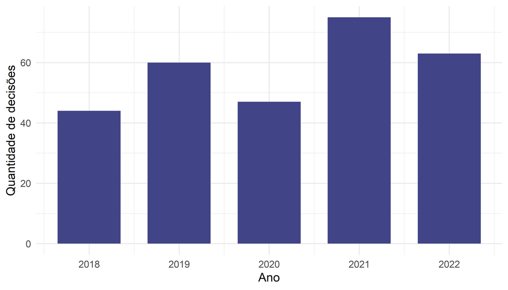

Figura 1: Quantidade de decisões por ano

A Figura 2 mostra o volume de decisões ao longo do tempo, separando por categoria de caso. Com exceção das ações de Anulação, é possível observar um crescimento de casos nos anos de 2021 e 2022.

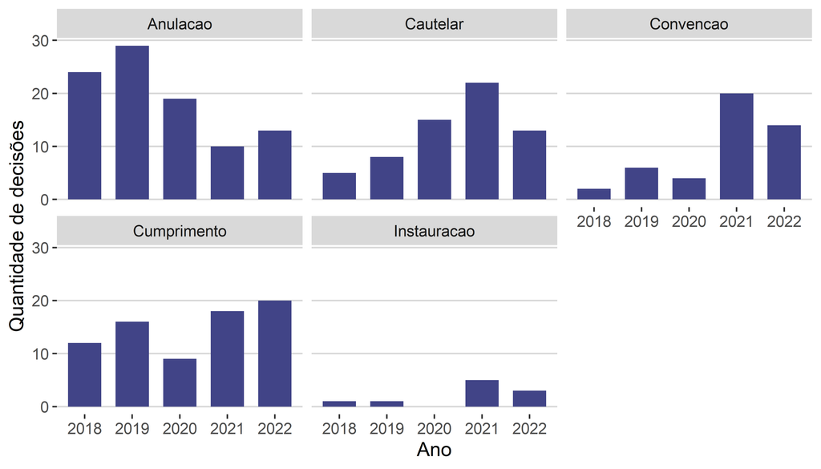

Figura 2: Quantidade de decisões por ano e categoria

A Tabela 12 mostra os resultados dos processos por categoria, excluindo os acordos. Nas últimas linha e coluna, são apresentadas as contagens e proporções marginais. A proporção de casos extintos observada é mais alta do que o comum em análises de processos do TJSP. A taxa de procedência em anulatórias (considerando casos procedentes e parcialmente procedentes e excluindo acordos do denominador) é de 44%, quando considerados os casos da Unimed. Excluídos os casos da Unimed, a taxa de procedência cai para 17%, conforme indicado na Tabela 15.

Tabela 12: Resultados dos processos por categoria, excluindo acordos

| Categoria | Extinto | Improcedente | Parcial | Procedente | Total |
| --- | --- | --- | --- | --- | --- |
| Anulacao | 6 (6%) | 46 (49%) | 16 (17%) | 25 (27%) | 93 (38%) |
| Cautelar | 40 (74%) | 10 (19%) | 0 (0%) | 4 (7%) | 54 (22%) |
| Convencao | 34 (74%) | 1 (2%) | 5 (11%) | 6 (13%) | 46 (19%) |
| Cumprimento | 44 (98%) | 0 (0%) | 1 (2%) | 0 (0%) | 45 (18%) |
| Instauracao | 0 (0%) | 0 (0%) | 0 (0%) | 8 (100%) | 8 (3%) |
| Total | 124 (50%) | 57 (23%) | 22 (9%) | 43 (17%) | 289 (100%) |

A partir da Tabela 12, é importante colocar um comentário sobre o **viés de seleção em decisões judiciais** (Priest e Klein 1984). Os processos que se manifestam no judiciário (por exemplo, ações de anulação de decisão arbitral) são uma amostra de todos os conflitos arbitrais, já que apenas uma parte dos casos vai para o judiciário. No entanto, essa amostra não é aleatória, já que a as probabilidades de dois casos irem ao judiciário após decisão arbitral não são as mesmas.

Os casos selecionados para serem judicializados são avaliados pelas partes e advogados de ambos os polos de acordo com suas características, em especial se i) há uma probabilidade ponderável do caso ser julgado favoravelmente sob sua perspectiva e ii) o montante do benefício econômico, considerada a probabilidade de êxito, compensa os custos de litigar, incluindo taxas, honorários com advogados, tempo, esforço e verbas sucumbenciais.

Como o caso é selecionado para ser judicializado quando tanto autor como réu consideram suas chances de êxito relevantes, ambos em média tendem a acertar, uma vez que não há elementos para considerar que um dos polos seria sistematicamente mais competente na avaliação de suas chances do que o outro. Por essa razão, as taxas de procedência de ações judiciais tendem, dadas certas condições (acesso a precedentes, custos para litigar e possibilidade de as partes transigirem), a 50%.

Nas discussões sobre a relação entre Poder Judiciário e arbitragem, a comunidade apresentou uma tendência a superestimar a importância das taxas de procedência como medida para a funcionalidade do sistema: quanto menor a taxa, mais funcional a relação. No entanto, esse mecanismo de seleção de casos serve para relativizar a importância das análises de taxas de procedência nesse contexto.

Assim, um importante resultado de Priest e Klein (1984) é que, considerando algumas premissas do sistema judiciário (como simetria de informação e existência de custos para litigar), **a taxa de decisões favoráveis no judiciário é diferente da probabilidade de reforma da decisão arbitral, compondo duas grandezas que não podem ser confundidas**. Falando especificamente dos resultados dessa pesquisa, as taxas de 44% e 17% (com e sem Unimed, respectivamente) não devem ser interpretadas como a probabilidade geral para se reverter uma decisão arbitral no judiciário.

A intensidade da seleção pode ser medida, pelo menos de forma aproximada, a partir de estatísticas da quantidade de decisões arbitrais no mesmo período do estudo. Pela Tabela 11, foi identificada uma taxa de seleção de aproximadamente 2.8% sem considerar processos em segredo de justiça. Ainda que a taxa real fosse de 10%, mais de três vezes a quantidade de casos públicos, a reforma das decisões arbitrais em primeira instância, considerando o mecanismo de seleção, **seria de 1.7%**[^4]. Essa sim seria uma estimativa conservadora para a probabilidade de reverter uma decisão arbitral no judiciário.

A Figura 3 mostra os resultados dos processos por categoria e vara, considerando apenas as duas varas empresariais. A quantidade de processos é muito pequena para obter resultados conclusivos, mas aparentemente a segunda vara tende a dar mais resultados procedentes ou parcialmente procedentes nas ações anulatórias.

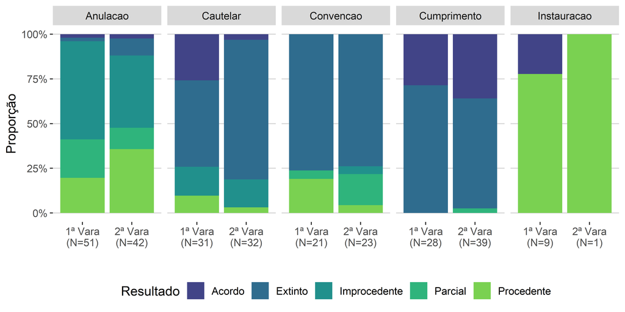

Figura 3: Proporção dos resultados dos processos por categoria e vara

Finalmente, a Tabela 13 mostra os tempos médios e medianos, geral e por categoria, em dias. Os processos mais longos são os de convenção arbitral, com mediana de quase um ano. Já os processos mais curtos são os de anulação, com mediana de aproximadamente seis meses.

Tabela 13: Estatísticas descritivas dos tempos dos processos em dias

| Categoria | N | Média | Mediana |
| --- | --- | --- | --- |
| Convencao | 46 | 353.6 | 328.5 |
| Instauracao | 10 | 462.7 | 301.0 |
| Cumprimento | 75 | 306.5 | 251.0 |
| Cautelar | 63 | 232.7 | 194.0 |
| Anulacao | 95 | 274.6 | 188.0 |
| Total | 289 | 292.8 | 227.0 |

## Questões adicionais

Após a revisão das análises, um novo conjunto de perguntas foi gerado. As perguntas foram respondidas com os gráficos e tabelas que seguem.

### Como ficam as estatísticas retirando casos envolvendo a Unimed?

A Unimed aparenta ser um caso de endemia processual (uma concentração grande de casos em torno de uma questão específica ou parte), que leva a um aumento na quantidade de casos de uma população de interesse. Por seguir um fluxo diferente, é de interesse recalcular as principais estatísticas do estudo retirando os 58 casos da Unimed.

A Tabela 14 mostra a contagem de processos por faixa de valores de causa nas anulatórias, retirando casos da Unimed. Quase um terço dos processos estão na faixa de 100 mil reais a 10 milhões, uma concentração parecida quando comparada Tabela 7.

Tabela 14: Faixas de valores nas anulatórias retirando casos da Unimed

| Faixa | N | % |
| --- | --- | --- |
| Até R$ 10.000 | 13 | 35.1% |
| Entre R$ 10.000 e R$ 100.000 | 8 | 21.6% |
| Entre R$ 100.000 e R$ 1 milhão | 7 | 18.9% |
| Entre R$ 1 milhão e R$ 10 milhões | 4 | 10.8% |
| R$ 10 milhões ou mais | 5 | 13.5% |
| Total | 37 | 100.0% |

A Tabela 15 mostra as proporções de resultados em processos de anulação retirando os casos da Unimed. A taxa de casos favoráveis (soma de procedentes e parcialmente procedentes excluindo acordos) é significativamente menor, de 17%.

Tabela 15: Resultados dos processos por categoria, excluindo acordos e casos da Unimed

| Categoria | Extinto | Improcedente | Parcial | Procedente | Total |
| --- | --- | --- | --- | --- | --- |
| Anulacao | 6 (17%) | 23 (66%) | 2 (6%) | 4 (11%) | 35 (19%) |
| Cautelar | 40 (74%) | 10 (19%) | 0 (0%) | 4 (7%) | 54 (29%) |
| Convencao | 34 (74%) | 1 (2%) | 5 (11%) | 6 (13%) | 46 (24%) |
| Cumprimento | 44 (98%) | 0 (0%) | 1 (2%) | 0 (0%) | 45 (24%) |
| Instauracao | 0 (0%) | 0 (0%) | 0 (0%) | 8 (100%) | 8 (4%) |
| Total | 124 (66%) | 34 (18%) | 8 (4%) | 22 (12%) | 289 (100%) |

A Figura 4 mostra os resultados dos processos por categoria e vara, considerando apenas as duas varas empresariais e retirando casos da Unimed. Novamente, a quantidade de processos é muito pequena para obter resultados conclusivos.

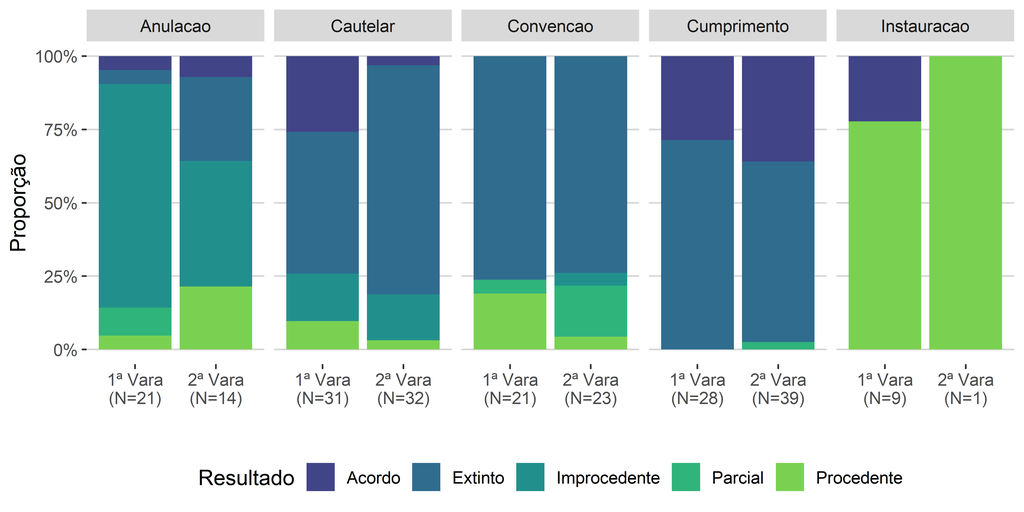

Figura 4: Proporção dos resultados dos processos por categoria e vara, retirando casos da Unimed

A Tabela 16 mostra os tempos médios e medianos, geral e por categoria, retirando os casos da Unimed. Ao excluir os casos, os tempos médio e mediano das anulatórias aumentam em mais de 100 dias.

Tabela 16: Estatísticas descritivas dos tempos dos processos, retirando casos da Unimed

| Categoria | N | Média | Mediana |
| --- | --- | --- | --- |
| Convencao | 46 | 353.6 | 328.5 |
| Instauracao | 10 | 462.7 | 301.0 |
| Anulacao | 37 | 386.8 | 291.0 |
| Cumprimento | 75 | 306.5 | 251.0 |
| Cautelar | 63 | 232.7 | 194.0 |
| Total | 231 | 315.4 | 259.0 |

### Qual o percentual de liminares deferidas na categoria de ação cautelar?

A base contém 63 ações cautelares, pouco mais de um quinto da base completa. A Tabela 17 mostra os resultados das liminares nessas ações. É possível identificar que mais da metade dos casos, as liminares não são concedias. Importante destacar que, em 6 casos, a decisão liminar não foi encontrada.

Tabela 17: Resultados das liminares em ações cautelares.

| Resultado | N | % |
| --- | --- | --- |
| Não | 30 | 52.6% |
| Sim | 20 | 35.1% |
| Parcial | 7 | 12.3% |
| Total | 57 | 100.0% |

### Qual a média e mediana de valor para cada categoria de ação?

A Tabela 18 mostra os valores médios e medianos das causas, geral e por categoria. Os processos de maior valor são as anulatórias, com mediana de R$ 264.802,79. Já os processos de menor valor são as cautelares e instauração, com mediana de dez mil reais, provavelmente colocados apenas como valores de referência.

Tabela 18: Estatísticas descritivas dos valores de causa dos processos

| Categoria | N | Média | Mediana |
| --- | --- | --- | --- |
| Anulacao | 95 | R$ 3.601.345,63 | R$ 264.802,79 |
| Convencao | 46 | R$ 10.081.664,83 | R$ 83.815,77 |
| Cumprimento | 75 | R$ 1.394.104,16 | R$ 23.468,15 |
| Cautelar | 63 | R$ 3.326.566,44 | R$ 10.000,00 |
| Instauracao | 10 | R$ 25.058,13 | R$ 10.000,00 |
| Total | 289 | R$ 3.884.973,58 | R$ 80.355,58 |

A Tabela 19 mostra as mesmas informações anteriores, mas retirando os casos da Unimed. É interessante notar que, no caso das anulatórias, o valor mediano é menor, mas o valor médio é maior que na Tabela 18. Isso indica que na amostra de anulatórias sem Unimed, a assimetria nos valores de causa é maior.

Tabela 19: Estatísticas descritivas dos valores de causa dos processos, retirando casos da Unimed

| Categoria | N | Média | Mediana |
| --- | --- | --- | --- |
| Convencao | 46 | R$ 10.081.664,83 | R$ 83.815,77 |
| Anulacao | 37 | R$ 6.385.684,12 | R$ 75.000,00 |
| Cumprimento | 75 | R$ 1.394.104,16 | R$ 23.468,15 |
| Cautelar | 63 | R$ 3.326.566,44 | R$ 10.000,00 |
| Instauracao | 10 | R$ 25.058,13 | R$ 10.000,00 |
| Total | 231 | R$ 4.404.412,48 | R$ 23.489,08 |

### Qual é a taxa de favorabilidade em anulatórias ao longo do tempo?

A Figura 5 mostra a taxa de casos favoráveis (procedentes e parcialmente procedentes) em ações anulatórias por ano, retirando casos de acordo. Apesar da pequena quantidade de dados, é possível observar que a proporção de decisões favoráveis detectada em 2021 e 2022 é menor.

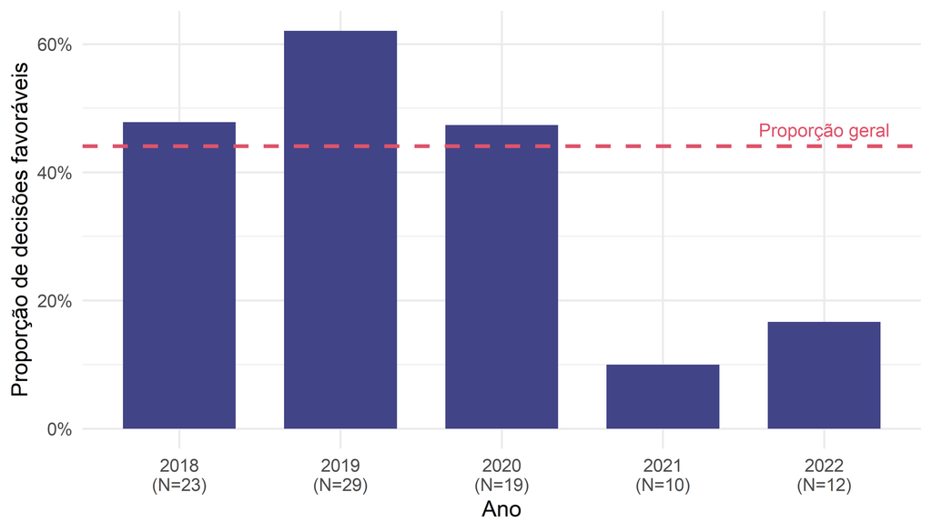

Figura 5: Proporção de decisões favoráveis por ano, retirando acordos

### Segunda instância

A Tabela Tabela 20 mostra os status dos processos de acordo com as categorias fornecidas pelo TJSP no momento de coleta. Quase 41% dos recursos foram encerrados e 26% foram arquivados administrativamente.

Tabela 20: Status dos processos na segunda instância de acordo com as categorias fornecidas pelo TJSP

| Staus | N | % |
| --- | --- | --- |
| Encerrado | 70 | 40.5% |
| Arquivado administrativamente | 45 | 26.0% |
| Remetido a Outro Tribunal | 24 | 13.9% |
| Ativo | 18 | 10.4% |
| Julgado | 15 | 8.7% |
| Processo não distribuído | 1 | 0.6% |

A taxa de recorribilidade estimada é de quase 60% (173 de 289 casos). Dividindo as taxas por categoria de processo, encontra-se o resultado da Tabela 21. A tabela também apresenta a quantidade de casos com alguma decisão (os demais continuam ativos, aguardando decisão). É possível notar que as anulatórias são as que apresentam maior taxa de recorribilidade.

Tabela 21: Quantidade e taxa de recorribilidade por categoria.

| Categoria | N total | N com recursos | N com decisão | Taxa recorribilidade |
| --- | --- | --- | --- | --- |
| Anulacao | 95 | 88 | 78 | 92.6% |
| Cautelar | 63 | 41 | 28 | 65.1% |
| Convencao | 46 | 30 | 14 | 65.2% |
| Cumprimento | 75 | 9 | 7 | 12.0% |
| Instauracao | 10 | 5 | 5 | 50.0% |
| Total | 289 | 173 | 132 | 59.9% |

A Tabela 22 mostra as mesmas estatísticas excluindo os casos da Unimed. A taxa de recorribilidade estimada é de 50% (116 de 231 casos). Dividindo as taxas por categoria de processo, é possível notar que as anulatórias permanecem com maior taxa de recorribilidade.

Tabela 22: Quantidade e taxa de recorribilidade por categoria, retirando casos da Unimed

| Categoria | N total | N com recursos | N com decisão | Taxa recorribilidade |
| --- | --- | --- | --- | --- |
| Anulacao | 37 | 31 | 22 | 83.8% |
| Cautelar | 63 | 41 | 28 | 65.1% |
| Convencao | 46 | 30 | 14 | 65.2% |
| Cumprimento | 75 | 9 | 7 | 12.0% |
| Instauracao | 10 | 5 | 5 | 50.0% |
| Total | 231 | 116 | 76 | 50.2% |

Como mostrado na Tabela 21, 173 casos com algum recurso, 132 (76%) apresentam alguma decisão. Os demais 41 casos (24%) ainda estavam ativos no momento de coleta dos dados, aguardando julgamento no segundo grau. Dos 132 casos que apresentam alguma decisão, 78 são anulatórias.

A Tabela 23 apresenta a taxa de recursos providos ou providos em parte por tipo de recurso. Considerando apenas as anulatórias com alguma decisão (78 casos), a taxa de recursos providos ou providos em parte é de 41% (32 de 78 casos).

Tabela 23: Taxa de recursos provido ou providos em parte por categoria

| Categoria | N decisões | % Provido |
| --- | --- | --- |
| Anulacao | 78 | 41.0% |
| Cautelar | 28 | 17.9% |
| Convencao | 14 | 14.3% |
| Cumprimento | 7 | 42.9% |
| Instauracao | 5 | 40.0% |

A Tabela 24 apresenta as mesmas taxas da Tabela 23 excluindo casos da Unimed. Considerando apenas as anulatórias com alguma decisão (22 casos), a taxa de recursos providos ou providos em parte é de 14% (3 de 22 casos).

Tabela 24: Taxa de recursos provido ou providos em parte por categoria, excluindo casos da Unimed.

| Categoria | N decisões | % Provido |
| --- | --- | --- |
| Anulacao | 22 | 13.6% |
| Cautelar | 28 | 17.9% |
| Convencao | 14 | 14.3% |
| Cumprimento | 7 | 42.9% |
| Instauracao | 5 | 40.0% |

### Reforma da decisão arbitral em segunda instância

Uma possível análise de interesse é a **reforma da decisão arbitral em segunda instância**. Quando se observa um recurso provido, isso não significa, necessariamente, que a decisão arbitral em si foi reformada, já que o recurso pode reverter uma sentença de procedência da anulatória, o que mantém a decisão tomada em foro arbitral. É importante destacar que essa análise está sendo feita em segunda instância, ou seja, aqui existem dois mecanismos de seleção: um da decisão arbitral para a sentença da anulatória, e outra da sentença judicial até o acórdão. Por isso, destaca-se, novamente, que a taxa apresentada não deve ser interpretada como a probabilidade de reverter uma decisão arbitral.

A análise da reforma foi realizada considerando as anulatórias. Dos 78 recursos em anulatórias que apresentam alguma decisão, 75 são decisões de mérito. Ou seja, são 75 os casos que tiveram alguma decisão que poderiam reformar a sentença arbitral.

Dos 75 casos com decisão de mérito, foi identificado que 28 (37%) reformaram a decisão arbitral. Isso significa que, após todos os mecanismos de seleção, ou seja, da decisão arbitral para a entrada do processo em primeira instância, e da sentença em primeira instância para o recurso, os poucos casos que sobram apresentam uma taxa de reforma de 37%.

Finalmente, retirando as decisões envolvendo a Unimed, observam-se 22 anulatórias, sendo que 20 delas apresentam decisão de mérito. Desses 20 recursos, apenas 1 caso apresentou reforma da decisão arbitral. Ou seja, mesmo após todos os mecanismos de seleção, ao retirar a Unimed, a reforma da decisão arbitral a partir de ações anulatórias na fase recursal é bastante rara.

# Referências

Priest, George L, e Benjamin Klein. 1984. «The selection of disputes for litigation». *The journal of legal studies* 13 (1): 1–55.

Zhao, Bo. 2017. «Web Scraping». *Encyclopedia of big data*, 1–3.

## Notas de rodapé

[^1]: Classes e assuntos são listas de tipos de processos organizadas pelo Conselho Nacional de Justiça (CNJ), através das Tabelas Processuais Unificadas (TPU), Res. 46 CNJ.
[^2]: As três primeiras varas empresariais tiveram sua criação autorizada no dia 14 de dezembro por deliberação unânime do Órgão Especial do Tribunal de Justiça do Estado de São Paulo. Link para o parecer em https://bit.ly/parecer-varas. Acesso em 03 de maio de 2023.
[^3]: O critério de exclusão dizia respeito à pertinência do caso ao objeto da pesquisa. Assim, casos nos quais as expressões apresentavam significados distintos (falsos cognatos) foram excluídos. Por exemplo, arbitragem no sentido de arbitragem de preço e não como método de resolução de disputas. Em outros as expressões apareciam por conta de citações acidentais em precedentes e excertos de doutrina, a despeito do caso em si não tratar do tema de interesse. Por fim, um caso identificado em uma nova categoria “Carta Arbitral” (1099760-61.2021.8.26.0100) também foi desconsiderado da análise.
[^4]: A taxa considera as decisões sem Unimed (17%), já que a Câmara da Unimed não faz parte do levantamento de sentenças arbitrais.